# l6_quant_ii_en2

Research Seminar

Dplyr, sampling and inference

Sergi Martínez

smsoler@clio.uc3m.es | Office hours: Tuesdays from 10:00 to 13:00

## Today

- R:
  - Dplyr
- Stats
  - Sampling and the central limit theorem
  - p-value
  - t-test and Chi2
  - Covariance and correlation
  - Regression

Before we start: you can access the data (L6 Data) and the code (L6 Script) for this seminar on [GitHub](https://github.com/sergimartinez/Semi3536)

**dplyr**

## 2 main components

**Pipes** (%>%) and verbs

did_something <- do_something(data)

did_another_thing <- do_another_thing(did_something)

last_thing <- do_last_thing(did_another_thing)

last_thing <- do_last_thing(

do_another_thing(

```
do_something(

  data)))
```

last_thing <- data%>% do_something()%>% do_another_thing()%>% do_last_thing()

last_thing <- data |> do_something() |> do_another_thing() |> do_last_thing()

## %>% == ‘and then’

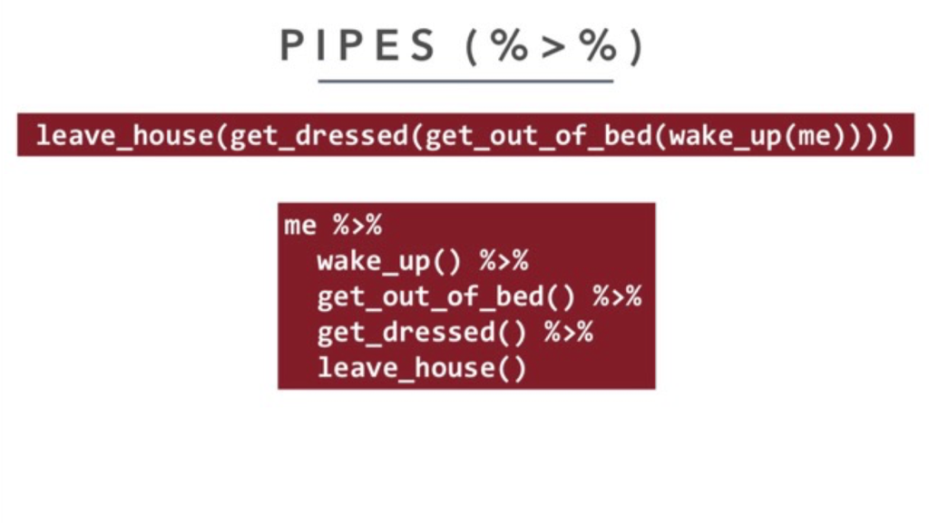

## dplyr verbs

| dplyr | base |
| --- | --- |
| `arrange(df, x)` | `df[order(x), , drop = FALSE]` |
| `distinct(df, x)` | `df[!duplicated(x), , drop = FALSE]`, `unique()` |
| `filter(df, x)` | `df[which(x), , drop = FALSE]`, `subset()` |
| `mutate(df, z = x + y)` | `df$z <- df$x + df$y`, `transform()` |
| `rename(df, y = x)` | `names(df)[names(df) == "x"] <- "y"` |
| `select(df, x, y)` | `df[c("x", "y")]`, `subset()` |
| `select(df, starts_with("x"))` | `df[grepl("^x", names(df))]` |
| `summarise(df, mean(x))` | `mean(df$x)`, `tapply()`, `aggregate()`, `by()` |

## (Mythical) example using gapminder

**Info/Data**: GDP - population over last 50y

*Source: [Gapminder](https://www.gapminder.org/data/)*

```r
# we download and load the package
# install.packages("gapminder")
library(gapminder)

gapminder_df <- gapminder::gapminder_unfiltered

head(gapminder_df)
```

```
# A tibble: 6 × 6
  country     continent  year lifeExp      pop gdpPercap
  <fct>       <fct>     <int>   <dbl>    <int>     <dbl>
1 Afghanistan Asia       1952    28.8  8425333      779.
2 Afghanistan Asia       1957    30.3  9240934      821.
3 Afghanistan Asia       1962    32.0 10267083      853.
4 Afghanistan Asia       1967    34.0 11537966      836.
5 Afghanistan Asia       1972    36.1 13079460      740.
6 Afghanistan Asia       1977    38.4 14880372      786.
```

## Filtering

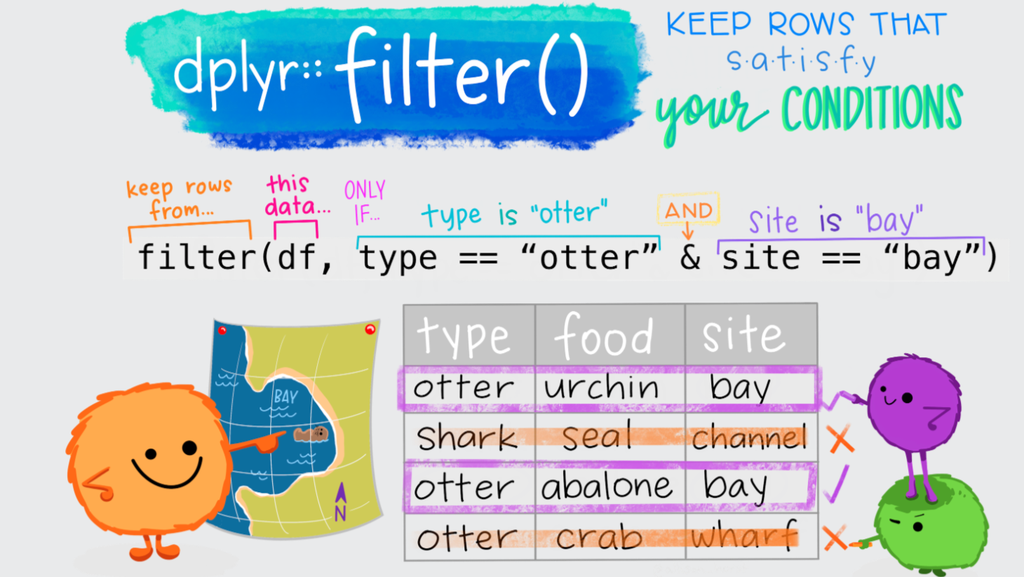